# Practical Machine Learning: Human Activity Recognition Assignment

Jacques Botes

December 2014

# Executive Summary

Using devices such as Jawbone Up, Nike FuelBand, and Fitbit it is now possible to collect a large amount of data about personal activity relatively inexpensively. More information about the data and the study can be found here http://groupware.les.inf.puc-rio.br/har. We will use the data provided to predict the manner in which 6 participants conduced their exercises. We used a random forest as it should give use the best accuracy. The classes was successfully predicted for the 6 participants, the approach is outlined in the approach section of the report.

## Approach

First we load all the necessary libraries and set the seed of the reproducibility of the random numbers in the assignment

We then download all the necessary files from the source. There are two files one containing the training data and a dataset with data of 6 participants that will be used as the test cases to predict the manner in which they did the exercise. We then create two data frames from the files and do basic cleanup in terms of how NA values should be treated.

```r
##for purposes of Reproducibility
file <- "data/pml-testing.csv"
if (!file.exists(file))
{
        url <- "https://d396qusza40orc.cloudfront.net/predmachlearn/pml-testing.csv"
        download.file(url,file,method="curl")
}
file <- "data/pml-training.csv"
if (!file.exists(file))
{
        url <- "https://d396qusza40orc.cloudfront.net/predmachlearn/pml-training.csv"
         download.file(url,file,method="curl")
}

 ##read data  for testing dataset
        filename <- "data/pml-testing.csv"
        pml.testing <- read.csv(filename,na.strings=c("NA",""),
                         header=TRUE)

 ##read data  for training dataset
        filename <- "data/pml-training.csv"
        pml.training <- read.csv(filename,na.strings=c("NA","#DIV/0!",""),
                         header=TRUE)
```

Lets do some exploratory analysis on the dataset.

We note 160 different columns in the training data and also note numerous of them contain NA values. There are a total of 100 columns that have more then 75% of the values in the column to have NA values. note: results of str not shown on report for length purposes.

We will now apply some transformations on the training dataset and apply the same on testing dataset afterwards, otherwise the model will fail. Firstly we remove all columns that wouldn’t impact int result significantly. We get all columns that have a near zero variance, these columns have very few unique values. We also remove columns that have NA values in more then 75% of the rows.

```r
rem.col.nzv <- nearZeroVar(pml.training)
pml.training.ss <- pml.training[,-rem.col.nzv]

##remove columns where more then 75% of the rows = NA
rem.col.na <- colSums(is.na(pml.training.ss)) < 0.75*nrow(pml.training.ss)
pml.training.ss <- pml.training.ss[,rem.col.na]
##Remove other cols.
rem.col <- c("X","user_name")
pml.training.ss <- pml.training.ss[,!names(pml.training.ss) %in% rem.col]

##Apply same column removals on testing set
pml.testing.ss <- pml.testing[,-rem.col.nzv]
pml.testing.ss <- pml.testing.ss[,rem.col.na]

##Remove other cols.
pml.testing.ss <- pml.testing.ss[,!names(pml.testing.ss) %in% rem.col]
pml.testing.ss <- pml.testing.ss[,!names(pml.testing.ss) %in% 'problem_id']
```

For training and testing of the model we split the training dataframe into 2 parts (60/40). This is to assist with the cross validation of the model and to calculate the error rate.

```r
##Partition the training set for cross validation purposes
pml.training.index <- createDataPartition(y=pml.training.ss$classe,p=0.6,list=FALSE)
pml.training.train <- pml.training.ss[pml.training.index,]
pml.training.validation <- pml.training.ss[-pml.training.index,]
```

For the model we will use a random forest model on the subset training data. We limit the number of trees growing to 150 for this model. This will ensure enough coverage of the predictors and will ensure the model doesnt take a long time to execute. We then use the model to predict the values for the 6 users in the testing dataset. We also apply the model on the validation dataset to determine the accuracy of the selected model.

```r
##subset the training data for training of the forest
##classe ~.
pml.model <- train(classe~., data=pml.training.train,method="rf", ntree=150)
##validation prediction
pml.val <- predict(pml.model,newdata=pml.training.validation)
##testing.
pml.pred <- predict(pml.model,newdata=pml.testing.ss)
```

Lets determine the out of sample error rate and the accuary of the model based on the validation sub set of data that was used.

```r
#calculate error rate and accuracy of the validation
ose.acc <- sum(pml.val == pml.training.validation$classe)/length(pml.val)
ose.err <- (1 - ose.acc)
##show confusion matrix
confusionMatrix(pml.training.validation$classe,pml.val)
```

```
## Confusion Matrix and Statistics
##
##           Reference
## Prediction    A    B    C    D    E
##          A 2232    0    0    0    0
##          B    2 1516    0    0    0
##          C    0    1 1365    2    0
##          D    0    0    5 1281    0
##          E    0    0    0    0 1442
##
## Overall Statistics
##
##                Accuracy : 0.9987
##                  95% CI : (0.9977, 0.9994)
##     No Information Rate : 0.2847
##     P-Value [Acc > NIR] : < 2.2e-16
##
##                   Kappa : 0.9984
##  Mcnemar's Test P-Value : NA
##
## Statistics by Class:
##
##                      Class: A Class: B Class: C Class: D Class: E
## Sensitivity            0.9991   0.9993   0.9964   0.9984   1.0000
## Specificity            1.0000   0.9997   0.9995   0.9992   1.0000
## Pos Pred Value         1.0000   0.9987   0.9978   0.9961   1.0000
## Neg Pred Value         0.9996   0.9998   0.9992   0.9997   1.0000
## Prevalence             0.2847   0.1933   0.1746   0.1635   0.1838
## Detection Rate         0.2845   0.1932   0.1740   0.1633   0.1838
## Detection Prevalence   0.2845   0.1935   0.1744   0.1639   0.1838
## Balanced Accuracy      0.9996   0.9995   0.9979   0.9988   1.0000
```

The accuracy of the model was calculated as 0.999 and the error rate (1-accuracy) was calculated to be 0.001. This indicates that the model was very accurate.

Now lets evaluate the results of the testing set that was provided.

```r
##plot
print(pml.model)
```

```
## Random Forest
##
## 11776 samples
##    56 predictor
##     5 classes: 'A', 'B', 'C', 'D', 'E'
##
## No pre-processing
## Resampling: Bootstrapped (25 reps)
##
## Summary of sample sizes: 11776, 11776, 11776, 11776, 11776, 11776, ...
##
## Resampling results across tuning parameters:
##
##   mtry  Accuracy   Kappa      Accuracy SD   Kappa SD
##    2    0.9886774  0.9856676  0.0023147899  0.002925101
##   38    0.9980537  0.9975371  0.0009298773  0.001175872
##   74    0.9968662  0.9960344  0.0010847652  0.001370960
##
## Accuracy was used to select the optimal model using  the largest value.
## The final value used for the model was mtry = 38.
```

```r
confusionMatrix(pml.model)
```

```
## Bootstrapped (25 reps) Confusion Matrix
##
## (entries are percentages of table totals)
##
##           Reference
## Prediction    A    B    C    D    E
##          A 28.6  0.0  0.0  0.0  0.0
##          B  0.0 19.4  0.0  0.0  0.0
##          C  0.0  0.0 17.4  0.0  0.0
##          D  0.0  0.0  0.0 16.3  0.0
##          E  0.0  0.0  0.0  0.0 18.2
```

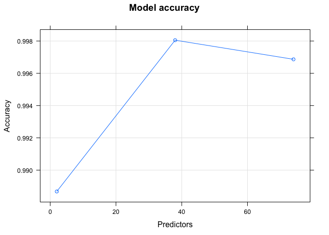

```r
plot(pml.model, log = "y",
     main = "Model accuracy",
     xlab = "Predictors",
     ylab = "Accuracy")
```

As seen in above plot and confusion Matrix that the model performed well at predicing the classes of the 6 users.

## Submission for grading

The final piece is to create the 20 submission files for the grading. The files was submitted and was 100% correct. the predicted classe results: B, A, B, A, A, E, D, B, A, A, B, C, B, A, E, E, A, B, B, B

```r
pml_write_files = function(x){
  n = length(x)
  for(i in 1:n){
    filename = paste0("output/","problem_id_",i,".txt")
    write.table(x[i],file=filename,quote=FALSE,row.names=FALSE,col.names=FALSE)
  }
}
pml_write_files(as.character(pml.pred))
```